# R Notebook

# Import Golder(+alesina+CLEA)

This file has been merged through STATA “legnewDOFILE.do” dofile.

```
## lattice theme set by effectsTheme()
## See ?effectsTheme for details.
```

```
## Install package "strengejacke" from GitHub (`devtools::install_github("strengejacke/strengejacke")`) to load all sj-packages at once!
```

```r
data <- read_dta("https://github.com/pgrau7/ES-0/blob/master/LegisCLEAN.dta?raw=true")
```

# Regressions replication

## Descriptive Statistics

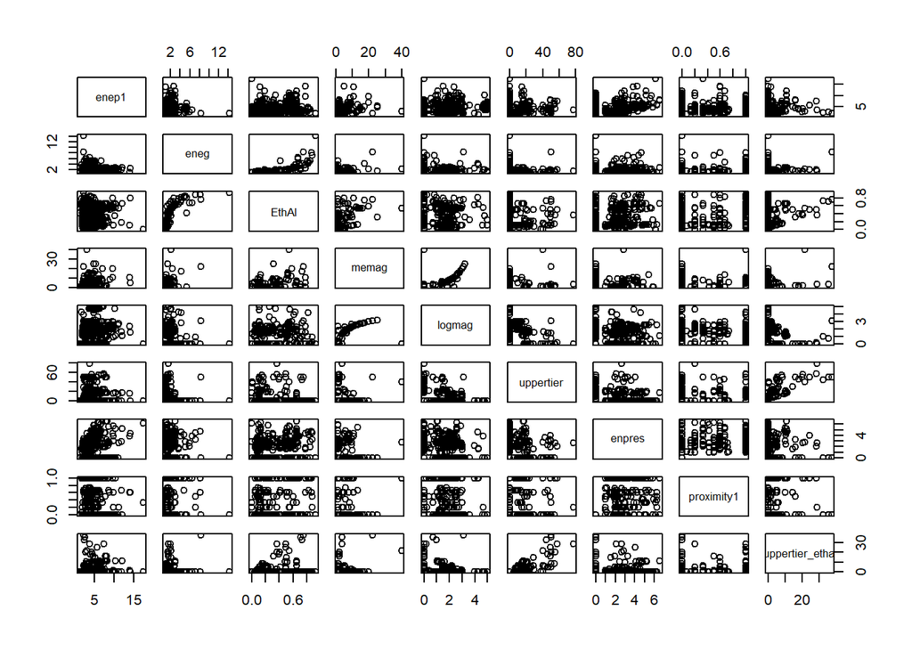

```r
myvars <- c("enep1", "eneg", "EthAl", "memag", "logmag", "uppertier", "enpres", "proximity1", "uppertier_ethal")
data1 <- data[myvars]
pairs(data1)
```

There are many 0’s! There’s linear or almost linear relationship on many variables, but the 0’s distort them. Can I treat them as NA?. How to deal with many 0s in one variable?

### Testing Ethnic Fractionalization

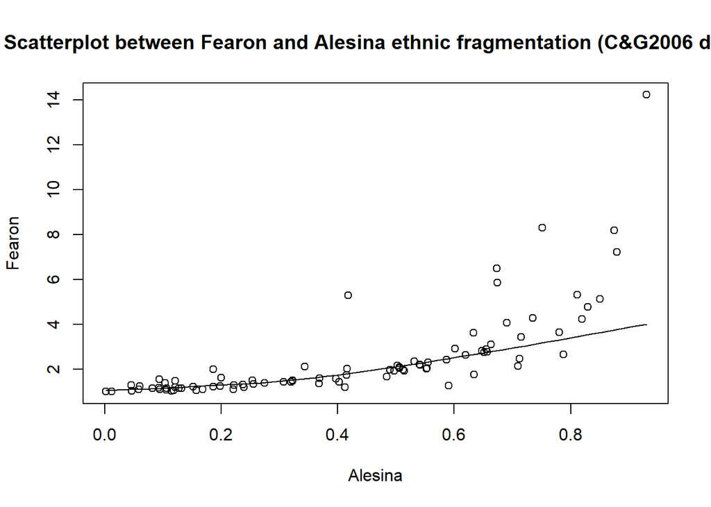

```r
scatter.smooth(data$EthAl, data$eneg, main="Scatterplot between Fearon and Alesina ethnic fragmentation (C&G2006 data)", xlab = "Alesina", ylab = "Fearon")
```

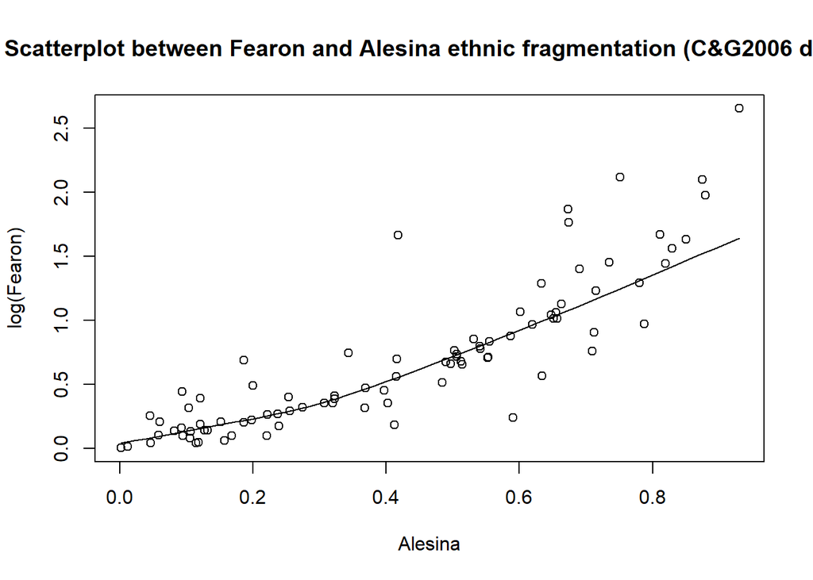

```r
scatter.smooth(data$EthAl, log(data$eneg), main="Scatterplot between Fearon and Alesina ethnic fragmentation (C&G2006 data)", xlab = "Alesina", ylab = "log(Fearon)")
```

```r
cor(data$EthAl, data$eneg, use = "complete.obs")
```

```
## [1] 0.6912115
```

```r
cor(data$EthAl, log(data$eneg), use = "complete.obs")
```

```
## [1] 0.8516942
```

The correlation between Alesina and Fearon in the data used is about 70%, which the same found by Alesina[^1]

## Cross sectional analysis

In the chunk below I replicate Golder’s cross sectional analyses. In the first two models (CS1 and CS1O) ethnic fractionalization is measured with Fearon (2003) data -provided by Clark & Golder (2006), whereas in the two next models (CS1AL, CS1OAL) Alesina is used.

```r
CS1 <- lm(enep1~eneg+logmag+uppertier+enpres+proximity1+logmag*eneg+uppertier*eneg+proximity1*enpres, data=subset(data, nineties==1))

CS1O <- lm(enep1~eneg+logmag+uppertier+enpres+proximity1+logmag*eneg+uppertier*eneg+proximity1*enpres, data=subset(data, nineties==1 & old==1))

CS1AL <- lm(enep1~EthAl+logmag+uppertier+enpres+proximity1+logmag*EthAl+uppertier*EthAl+proximity1*enpres, data=subset(data, nineties==1))

CS1OAL <- lm(enep1~EthAl+logmag+uppertier+enpres+proximity1+logmag*EthAl+uppertier*EthAl+proximity1*enpres, data=subset(data, nineties==1 & old==1))

#stargazer::stargazer(CS1, CS1AL, CS1O, CS1OAL, type="text", dep.var.caption  = "Cross-sectional analysis replication", column.labels = c("1990s Whole Sample", "1990s Whole Sample","1990s Established Democracies", "1990s Established Democracies"))
```

```r
stargazer::stargazer(CS1, CS1AL, CS1O, CS1OAL, type="html", dep.var.caption  = "Clark&Golder 2006 analysis replication: Fearon vs. Alesina",  column.labels = c("1990s Whole Sample (Fearon)","1990s Whole Sample (Alesina)", "1990s Established Democracies (Fearon)", "1990s Established Democracies (Alesina)"))
```

|  | Clark&Golder 2006 analysis replication: Fearon vs. Alesina |  |  |  |
| --- | --- | --- | --- | --- |
|  | enep1 |  |  |  |
|  | 1990s Whole Sample (Fearon) | 1990s Whole Sample (Alesina) | 1990s Established Democracies (Fearon) | 1990s Established Democracies (Alesina) |
|  | (1) | (2) | (3) | (4) |
| eneg | 0.061 |  | -0.703 |  |
|  | (0.371) |  | (0.677) |  |
| EthAl |  | 1.528 |  | -0.428 |
|  |  | (1.401) |  | (1.241) |
| logmag | 0.509 | 0.534 | -0.610 | 0.215 |
|  | (0.443) | (0.335) | (0.589) | (0.268) |
| uppertier | 0.011 | 0.045* | -0.022 | 0.014 |
|  | (0.025) | (0.025) | (0.058) | (0.023) |
| enpres | 0.364 | 0.501** | 0.067 | 0.221 |
|  | (0.257) | (0.231) | (0.216) | (0.194) |
| proximity1 | -4.194*** | -3.891*** | -4.950*** | -4.482*** |
|  | (1.258) | (1.083) | (1.239) | (1.082) |
| eneg:logmag | -0.095 |  | 0.625* |  |
|  | (0.168) |  | (0.340) |  |
| eneg:uppertier | -0.005 |  | 0.013 |  |
|  | (0.010) |  | (0.039) |  |
| EthAl:logmag |  | -0.412 |  | 1.308* |
|  |  | (0.671) |  | (0.777) |
| EthAl:uppertier |  | -0.107* |  | -0.001 |
|  |  | (0.057) |  | (0.074) |
| enpres:proximity1 | 0.985** | 0.887** | 1.423*** | 1.201*** |
|  | (0.456) | (0.418) | (0.435) | (0.386) |
| Constant | 4.075*** | 2.946*** | 5.152*** | 3.391*** |
|  | (0.954) | (0.701) | (1.325) | (0.550) |
| Observations | 62 | 78 | 39 | 51 |
| R<sup>2</sup> | 0.288 | 0.312 | 0.482 | 0.496 |
| Adjusted R<sup>2</sup> | 0.181 | 0.232 | 0.344 | 0.400 |
| Residual Std. Error | 2.081 (df = 53) | 1.927 (df = 69) | 1.411 (df = 30) | 1.322 (df = 42) |
| F Statistic | 2.683** (df = 8; 53) | 3.903*** (df = 8; 69) | 3.494*** (df = 8; 30) | 5.158*** (df = 8; 42) |
| *Note:* | p<0.1; p<0.05; p<0.01 |  |  |  |

From these results, Alesina’s measure seems to fit well the models:

- It has a higher number of observations in the dataset
- It presents a higher R<sup>2</sup>
- Results aren’t qualitetively different.

### Are assumptions met?

We should, though, see if the models fit with the assumptions of OLS. Let’s work with CS1AL -which had the biggest number of observations.

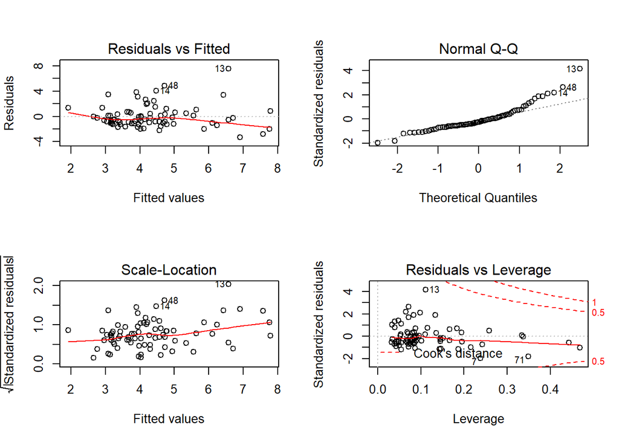

```r
par(mfrow = c(2, 2))
plot(CS1AL)+theme_bw()
```

```r
olsrr::ols_test_normality(CS1AL)
```

```
## -----------------------------------------------
##        Test             Statistic       pvalue
## -----------------------------------------------
## Shapiro-Wilk              0.8857         0.0000
## Kolmogorov-Smirnov        0.1476         0.0602
## Cramer-von Mises          8.2404         0.0000
## Anderson-Darling          2.7074         0.0000
## -----------------------------------------------
```

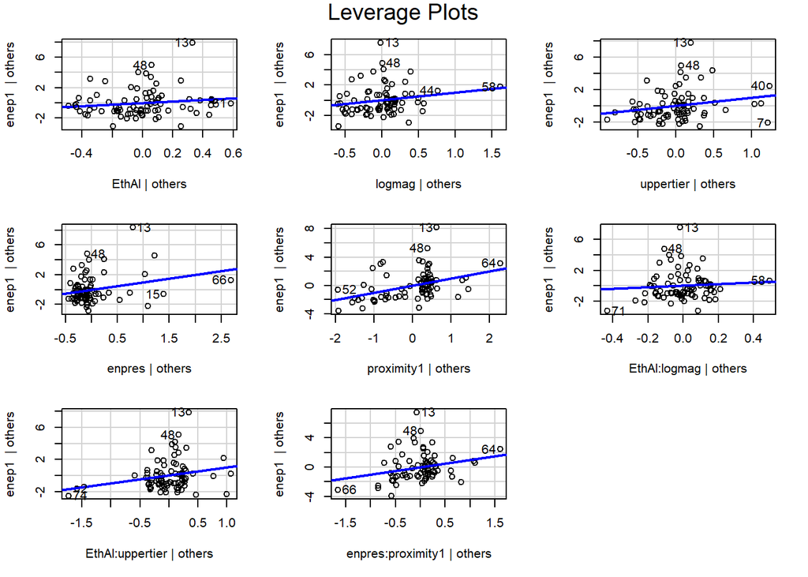

```r
leveragePlots(CS1AL)
```

- Heteroskedasticity: Breusch-Pagan test (bptest) has a value of BP = 13.936, df = 8, p-value = 0.08344. We fail to reject homoskedasticity at a 95% level.

```r
bptest(CS1AL)
```

```
##
##  studentized Breusch-Pagan test
##
## data:  CS1AL
## BP = 13.936, df = 8, p-value = 0.08344
```

- Multicollinearity: No problem (all less than 10, higher than 5 if interaction).

```r
vif(CS1AL)
```

```
##             EthAl            logmag         uppertier            enpres
##          2.406415          4.069856          4.119967          3.350340
##        proximity1      EthAl:logmag   EthAl:uppertier enpres:proximity1
##          4.806950          5.081636          3.944312          7.884060
```

## Pooled model

In order to have a more extensive sample, CG2006 included all observations of the dataset in the analysis. As it is panel data with different observations per each country (in different dates), an OLS model would have heteroskedasticity, which can be addressed by treating panel data as such: - Breusch-Pagan test: BP = 49.255, df = 8, p-value = 5.682e-08

```r
WS <- lm(log(enep1)~eneg+logmag+uppertier+enpres+proximity1+logmag_eneg+uppertier_eneg+proximity1_enpres, data=data)
bptest(WS)
```

```
##
##  studentized Breusch-Pagan test
##
## data:  WS
## BP = 49.255, df = 8, p-value = 5.682e-08
```

```r
#data1 <- data
#data <- data1[!(is.na(data1$year))]
```

```r
poolWS <- plm(enep1~eneg+logmag+uppertier+enpres+proximity1+eneg*logmag+uppertier*eneg+proximity1*enpres, data=data, index=c("country", "year"), model="pooling")
```

```
## at least one couple (id-time) has NA in at least one index dimensionin resulting pdata.frame
##  to find out which, use e.g.table(index(your_pdataframe), useNA = "ifany")
```

```r
robust_seWS <- sqrt(diag(vcovHC(poolWS, type = "HC1")))

poolWSAL <- plm(enep1~EthAl+logmag+uppertier+enpres+proximity1+logmag*EthAl+uppertier*EthAl+proximity1*enpres, data=data, index=c("country", "year"), model="pooling")
```

```
## at least one couple (id-time) has NA in at least one index dimensionin resulting pdata.frame
##  to find out which, use e.g.table(index(your_pdataframe), useNA = "ifany")
```

```r
robust_seWSAL <- sqrt(diag(vcovHC(poolWSAL, type = "HC1")))

poolED <- plm(enep1~eneg+logmag+uppertier+enpres+proximity1+logmag*eneg+uppertier*eneg+proximity1*enpres, data=subset(data, old==1), index=c("country", "year"), model="pooling")
```

```
## at least one couple (id-time) has NA in at least one index dimensionin resulting pdata.frame
##  to find out which, use e.g.table(index(your_pdataframe), useNA = "ifany")
```

```r
robust_seED <- sqrt(diag(vcovHC(poolED, type = "HC1")))

poolEDAL <- plm(enep1~EthAl+logmag+uppertier+enpres+proximity1+logmag*EthAl+uppertier*EthAl+proximity1*enpres, data=subset(data, old==1), index=c("country", "year"), model="pooling")
```

```
## at least one couple (id-time) has NA in at least one index dimensionin resulting pdata.frame
##  to find out which, use e.g.table(index(your_pdataframe), useNA = "ifany")
```

```r
robust_seEDAL <- sqrt(diag(vcovHC(poolEDAL, type = "HC1")))
```

```r
stargazer::stargazer(poolWS,poolWSAL, poolED,poolEDAL, type="html", dep.var.caption  = "Clark&Golder 2006 pooled analysis replication",  column.labels = c("1946 to 2000 ws pooled","1946 to 2000 ws pooled(alesina)", "1946 to 2000 EDP","1946 to 2000 EDP alesina" ), se=list(robust_seWS,robust_seWSAL, robust_seED, robust_seEDAL))
```

|  | Clark&Golder 2006 pooled analysis replication |  |  |  |
| --- | --- | --- | --- | --- |
|  | enep1 |  |  |  |
|  | 1946 to 2000 ws pooled | 1946 to 2000 ws pooled(alesina) | 1946 to 2000 EDP | 1946 to 2000 EDP alesina |
|  | (1) | (2) | (3) | (4) |
| eneg | 0.192 |  | 0.112 |  |
|  | (0.129) |  | (0.142) |  |
| EthAl |  | 0.377 |  | -0.012 |
|  |  | (0.712) |  | (0.680) |
| logmag | 0.330* | 0.306** | 0.078 | 0.271** |
|  | (0.195) | (0.119) | (0.228) | (0.113) |
| uppertier | 0.048*** | 0.033** | -0.057* | 0.013 |
|  | (0.015) | (0.015) | (0.033) | (0.016) |
| enpres | 0.345** | 0.457*** | 0.264* | 0.324** |
|  | (0.164) | (0.168) | (0.144) | (0.145) |
| proximity1 | -3.418*** | -3.177*** | -3.098*** | -2.886*** |
|  | (0.549) | (0.542) | (0.456) | (0.490) |
| eneg:logmag | 0.076 |  | 0.264 |  |
|  | (0.116) |  | (0.169) |  |
| eneg:uppertier | -0.016** |  | 0.059*** |  |
|  | (0.007) |  | (0.021) |  |
| EthAl:logmag |  | 0.491 |  | 0.957* |
|  |  | (0.424) |  | (0.502) |
| EthAl:uppertier |  | -0.050 |  | 0.044 |
|  |  | (0.047) |  | (0.067) |
| enpres:proximity1 | 0.800*** | 0.670*** | 0.683*** | 0.638*** |
|  | (0.229) | (0.216) | (0.228) | (0.212) |
| Constant | 2.811*** | 2.860*** | 2.916*** | 2.896*** |
|  | (0.338) | (0.248) | (0.344) | (0.235) |
| Observations | 555 | 661 | 487 | 587 |
| R<sup>2</sup> | 0.299 | 0.305 | 0.397 | 0.371 |
| Adjusted R<sup>2</sup> | 0.289 | 0.296 | 0.387 | 0.362 |
| F Statistic | 29.098*** (df = 8; 546) | 35.723*** (df = 8; 652) | 39.277*** (df = 8; 478) | 42.585*** (df = 8; 578) |
| *Note:* | p<0.1; p<0.05; p<0.01 |  |  |  |

# How to analyze Pooled models assumptions? And interpret margins?

Alesina has more values, we increase the df.

summary(poolWS, cluster=c(“country”))

fixedWS <- plm(enep~eneg+logmag+uppertier+enpres+proximity1+logmag_eneg+uppertier_eneg+proximity1_enpres, data=data, index=c(“country”, “year”), model=“within”)

summary(poolED) ##Genuine models

```r
poolEDAL1 <- plm(log(enep1)~eneg+logmag+uppertier+enpres+proximity1+logmag_eneg+uppertier_eneg+proximity1_enpres, data=subset(data, old==1), index=c("country", "year"), model="pooling")
```

```
## at least one couple (id-time) has NA in at least one index dimensionin resulting pdata.frame
##  to find out which, use e.g.table(index(your_pdataframe), useNA = "ifany")
```

```r
robust_seEDAL1 <- sqrt(diag(vcovHC(poolEDAL1, type = "HC1")))

stargazer::stargazer(poolEDAL, poolEDAL1, se=list(robust_seEDAL, robust_seEDAL1), type="text")
```

```
##
## =================================================================
##                                 Dependent variable:
##                   -----------------------------------------------
##                            enep1                log(enep1)
##                             (1)                     (2)
## -----------------------------------------------------------------
## EthAl                     -0.012
##                           (0.680)
##
## eneg                                               0.028
##                                                   (0.041)
##
## logmag                    0.271**                  0.060
##                           (0.113)                 (0.054)
##
## uppertier                  0.013                  -0.008
##                           (0.016)                 (0.007)
##
## enpres                    0.324**                  0.045
##                           (0.145)                 (0.035)
##
## proximity1               -2.886***               -0.804***
##                           (0.490)                 (0.121)
##
## EthAl:logmag              0.957*
##                           (0.502)
##
## EthAl:uppertier            0.044
##                           (0.067)
##
## enpres:proximity1        0.638***
##                           (0.212)
##
## logmag_eneg                                        0.044
##                                                   (0.037)
##
## uppertier_eneg                                    0.010**
##                                                   (0.004)
##
## proximity1_enpres                                0.196***
##                                                   (0.059)
##
## Constant                 2.896***                1.034***
##                           (0.235)                 (0.096)
##
## -----------------------------------------------------------------
## Observations                587                     487
## R2                         0.371                   0.419
## Adjusted R2                0.362                   0.409
## F Statistic       42.585*** (df = 8; 578) 43.097*** (df = 8; 478)
## =================================================================
## Note:                                 *p<0.1; **p<0.05; ***p<0.01
```

## Add variance

```r
poolEDAL1 <- plm(enep1~EthAl+logmag+uppertier+enpres+proximity1+logmag*EthAl+uppertier*EthAl+proximity1*enpres, data=subset(data, old==1&!is.na(data$varmag)), index=c("country", "year"), model="pooling")
```

```
## at least one couple (id-time) has NA in at least one index dimensionin resulting pdata.frame
##  to find out which, use e.g.table(index(your_pdataframe), useNA = "ifany")
```

```r
robust_seEDAL1 <- sqrt(diag(vcovHC(poolEDAL1, type = "HC1")))

lpoolEDAL1 <- plm(log(enep1)~EthAl+logmag+uppertier+enpres+proximity1+logmag*EthAl+uppertier*EthAl+proximity1*enpres, data=subset(data, old==1&!is.na(data$varmag)), index=c("country", "year"), model="pooling")
```

```
## at least one couple (id-time) has NA in at least one index dimensionin resulting pdata.frame
##  to find out which, use e.g.table(index(your_pdataframe), useNA = "ifany")
```

```r
robust_selEDAL1 <- sqrt(diag(vcovHC(lpoolEDAL1, type = "HC1")))

poolEDALv <- plm(enep1~EthAl+logmag+uppertier+enpres+proximity1+logmag*EthAl+uppertier*EthAl+proximity1*enpres+varmag, data=subset(data, old==1), index=c("country", "year"), model="pooling")
```

```
## at least one couple (id-time) has NA in at least one index dimensionin resulting pdata.frame
##  to find out which, use e.g.table(index(your_pdataframe), useNA = "ifany")
```

```r
robust_seEDALv <- sqrt(diag(vcovHC(poolEDALv, type = "HC1")))

lpoolEDALv <- plm(log(enep1)~EthAl+logmag+uppertier+enpres+proximity1+logmag*EthAl+uppertier*EthAl+proximity1*enpres+varmag, data=subset(data, old==1), index=c("country", "year"), model="pooling")
```

```
## at least one couple (id-time) has NA in at least one index dimensionin resulting pdata.frame
##  to find out which, use e.g.table(index(your_pdataframe), useNA = "ifany")
```

```r
robust_selEDALv <- sqrt(diag(vcovHC(lpoolEDALv, type = "HC1")))

poolEDALvx <- plm(enep1~EthAl+logmag+uppertier+enpres+proximity1+logmag*EthAl+uppertier*EthAl+proximity1*enpres+varmag+varmag*logmag, data=subset(data, old==1), index=c("country", "year"), model="pooling")
```

```
## at least one couple (id-time) has NA in at least one index dimensionin resulting pdata.frame
##  to find out which, use e.g.table(index(your_pdataframe), useNA = "ifany")
```

```r
robust_seEDALvx <- sqrt(diag(vcovHC(poolEDALvx, type = "HC1")))

lpoolEDALvx <- plm(log(enep1)~EthAl+logmag+uppertier+enpres+proximity1+logmag_ethal+uppertier_ethal+proximity1_enpres+varmag+varmag*logmag, data=subset(data, old==1), index=c("country", "year"), model="pooling")
```

```
## at least one couple (id-time) has NA in at least one index dimensionin resulting pdata.frame
##  to find out which, use e.g.table(index(your_pdataframe), useNA = "ifany")
```

```r
robust_selEDALvx <- sqrt(diag(vcovHC(lpoolEDALvx, type = "HC1")))
```

```r
stargazer::stargazer(poolEDAL, poolEDAL1, poolEDALv, poolEDALvx, type="html", dep.var.caption  = "Clark&Golder 2006 pooled analysis replication",  column.labels = c("1946 to 2000 ED","1946 to 2000 ED (reduced sample)", "additive model","interactive model" ), se=list(robust_seEDAL ,robust_seEDAL1, robust_seEDALv, robust_seEDALvx))
```

|  | Clark&Golder 2006 pooled analysis replication |  |  |  |
| --- | --- | --- | --- | --- |
|  | enep1 |  |  |  |
|  | 1946 to 2000 ED | 1946 to 2000 ED (reduced sample) | additive model | interactive model |
|  | (1) | (2) | (3) | (4) |
| EthAl | -0.012 | 0.163 | 0.143 | 0.126 |
|  | (0.680) | (0.546) | (0.555) | (0.553) |
| logmag | 0.271** | 0.288 | 0.198 | 0.197 |
|  | (0.113) | (0.247) | (0.261) | (0.266) |
| uppertier | 0.013 | 0.017** | 0.019*** | 0.021*** |
|  | (0.016) | (0.008) | (0.007) | (0.008) |
| enpres | 0.324** | 0.351* | 0.318 | 0.328 |
|  | (0.145) | (0.198) | (0.208) | (0.205) |
| proximity1 | -2.886*** | -1.665*** | -1.571*** | -1.668*** |
|  | (0.490) | (0.558) | (0.553) | (0.551) |
| varmag |  |  | 0.020 | 0.042* |
|  |  |  | (0.020) | (0.022) |
| EthAl:logmag | 0.957* | 0.451 | -0.322 | 0.011 |
|  | (0.502) | (0.532) | (0.941) | (0.970) |
| EthAl:uppertier | 0.044 | -0.002 | -0.022 | -0.043 |
|  | (0.067) | (0.045) | (0.038) | (0.038) |
| enpres:proximity1 | 0.638*** | 0.267 | 0.276 | 0.277 |
|  | (0.212) | (0.242) | (0.241) | (0.234) |
| logmag:varmag |  |  |  | -0.012 |
|  |  |  |  | (0.008) |
| Constant | 2.896*** | 2.759*** | 2.777*** | 2.777*** |
|  | (0.235) | (0.177) | (0.181) | (0.182) |
| Observations | 587 | 247 | 247 | 247 |
| R<sup>2</sup> | 0.371 | 0.266 | 0.285 | 0.294 |
| Adjusted R<sup>2</sup> | 0.362 | 0.242 | 0.258 | 0.264 |
| F Statistic | 42.585*** (df = 8; 578) | 10.800*** (df = 8; 238) | 10.484*** (df = 9; 237) | 9.817*** (df = 10; 236) |
| *Note:* | p<0.1; p<0.05; p<0.01 |  |  |  |

Some observations: - Increasing R<sup>2</sup> , both adjusted and not. - Significance for interactions is not relevant, we should plot the expected marginal effect (How?)

### log(ENEP1)

```r
#library(effects)
#plot(predictorEffect("eneg", poolED))

#jtools::effect_plot(poolED, pred = eneg, interval = TRUE, plot.points = TRUE)

#margins::margins.plm(poolED)
```

# Replying Clark&Goler with the new dataset

```r
newdata <- readr::read_csv2(url("https://raw.githubusercontent.com/pgrau7/ES-0/master/Merging%20datasets/FINAL_DATA.csv"))
newdata$EthAl <- as.numeric(newdata$EthAl)
pdata <- pdata.frame(newdata, index = c("country","date.x"))
pdata$logmag <- log(pdata$memag)
pdata$logmag_ethal <- pdata$logmag*pdata$EthAl
pdata$uppertier_ethal <- pdata$uppertier*pdata$EthAl


#poolEDAL <- plm(log(enep1)~EthAl+log(memag)+uppertier+log(memag)*EthAl+uppertier*EthAl, data=subset(data, old==1), index=c("country", "year"), model="pooling")
poolEDAL<- plm(log(enep1)~EthAl+logmag+uppertier+logmag_ethal+uppertier_ethal, data=subset(data, old==1), index=c("country", "year"), model="pooling")
robust_seEDAL <- sqrt(diag(vcovHC(poolEDAL, type = "HC1")))

poolEDAL1 <- plm(log(enep1)~EthAl+logmag+uppertier+enpres+proximity1+logmag_ethal+uppertier_ethal+proximity1_enpres, data=subset(data, old==1&!is.na(data$varmag)), index=c("country", "year"), model="pooling")
robust_seEDAL1 <- sqrt(diag(vcovHC(poolEDAL1, type = "HC1")))

poolEDALv <- plm(log(enep1)~EthAl+logmag+uppertier+enpres+proximity1+logmag_ethal+uppertier_ethal+proximity1_enpres+varmag, data=subset(data, old==1), index=c("country", "year"), model="pooling")
robust_seEDALv <- sqrt(diag(vcovHC(poolEDALv, type = "HC1")))

poolEDALvx <- plm(log(enep1)~EthAl+logmag+uppertier+enpres+proximity1+logmag_ethal+uppertier_ethal+proximity1_enpres+varmag+varmag*logmag, data=subset(data, old==1), index=c("country", "year"), model="pooling")
robust_seEDALvx <- sqrt(diag(vcovHC(poolEDALvx, type = "HC1")))

xR5 <- plm(log(enep1)~EthAl+logmag+uppertier+logmag_ethal+uppertier_ethal+(log1p(varmag)*log1p(memag)), data=pdata, index=c("country", "date.x"), model="pooling", pooling=TRUE)
robust_seR5pooled1 <- sqrt(diag(vcovHC(xR5, type = "HC1")))

R5 <- lm(log(enep1)~EthAl+logmag+uppertier+logmag_ethal+uppertier_ethal+(log1p(varmag)*log1p(memag)), data=pdata)
```

[^1]: Alesina, A., & Ferrara, E. La. (2005). Ethnic Diversity and Economic Performance. Journal of Economic Literature (Vol. XLIII).